# Case Study: Predicting Airline Delays

Máster en Data Science y Big Data en Finanzas

AFI, 2022

# Introduction

On any given day, more than 90,000 flights operate in the US. About one-third of these flights are commercial flights, operated by companies like United, American Airlines, etc. Among these commercial flights, 20% suffer from delays due to various reasons. A certain number of delays are unavoidable, due to unexpected events, but some delays could hopefully be avoided if the factors causing delays are better understood and addressed.

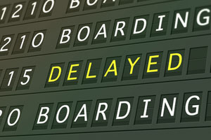

In this case study, we will use a dataset with 9,381 flights that occurred in June-August, 2014 between the three busiest US airports:

- Atlanta (ATL)
- Los Angeles (LAX)
- Chicago (ORD)

### The dataset

The dataset AirlineDelay.csv includes the following 23 variables:

- Flight = the origin-destination pair (LAX-ORD, ATL-LAX, etc.)
- Carrier = the carrier operating the flight (American Airlines, Delta Air Lines, etc.)
- Month = the month of the flight (June, July, or August)
- DayOfWeek = the day of the week of the flight (Monday, Tuesday, etc.)
- NumPrevFlights = the number of previous flights taken by this aircraft in the same day
- PrevFlightGap = the amount of time between when this flight’s aircraft is scheduled to arrive at the airport and when it’s scheduled to depart for this flight
- HistoricallyLate = the proportion of time this flight has been late historically
- InsufficientHistory = whether or not we have enough data to determine the historical record of the flight (equal to 1 if we don’t have at least 3 records, equal to 0 if we do)
- OriginInVolume = the amount of incoming traffic volume at the origin airport, normalized by the typical volume during the flight’s time and day of the week
- OriginOutVolume = the amount of outgoing traffic volume at the origin airport, normalized by the typical volume during the flight’s time and day of the week
- DestInVolume = the amount of incoming traffic volume at the destination airport, normalized by the typical volume during the flight’s time and day of the week
- DestOutVolume = the amount of outgoing traffic volume at the destination airport, normalized by the typical volume during the flight’s time and day of the week
- OriginPrecip = the amount of rain at the origin over the course of the day, in tenths of millimeters
- OriginAvgWind = average daily wind speed at the origin, in miles per hour
- OriginWindGust = fastest wind speed during the day at the origin, in miles per hour
- OriginFog = whether or not there was fog at some point during the day at the origin (1 if there was, 0 if there wasn’t)
- OriginThunder = whether or not there was thunder at some point during the day at the origin (1 if there was, 0 if there wasn’t)
- DestPrecip = the amount of rain at the destination over the course of the day, in tenths of millimeters
- DestAvgWind = average daily wind speed at the destination, in miles per hour
- DestWindGust = fastest wind speed during the day at the destination, in miles per hour
- DestFog = whether or not there was fog at some point during the day at the destination (1 if there was, 0 if there wasn’t)
- DestThunder = whether or not there was thunder at some point during the day at the destination (1 if there was, 0 if there wasn’t)
- TotalDelay = the amount of time the aircraft was delayed, in minutes (this is our dependent variable)

### The goal

Predict the response TotalDelay as a function of the other variables

### Descriptive Analysis

It is always a good idea to separate from the beginning the training set (what the tool is going to see) from the testing set (used only to validate predictions)

```r
library(tidyverse)
library(MASS)
library(caret)
library(e1071)

# Loading and preparing data
Airlines <- read.csv("AirlineDelay.csv", stringsAsFactors = T)

# split between training and testing sets
spl = createDataPartition(Airlines$TotalDelay, p = 0.8, list = FALSE)  # 80% for training

AirlinesTrain = Airlines[spl,]
AirlinesTest = Airlines[-spl,]

str(AirlinesTrain)
```

```
## 'data.frame':    7506 obs. of  23 variables:
##  $ Flight             : Factor w/ 6 levels "ATL-LAX","ATL-ORD",..: 4 4 4 4 4 4 4 4 4 4 ...
##  $ Carrier            : Factor w/ 8 levels "AirTran Airways",..: 2 2 2 2 2 2 2 2 2 2 ...
##  $ Month              : Factor w/ 3 levels "August","July",..: 3 3 3 3 3 3 3 3 3 3 ...
##  $ DayOfWeek          : Factor w/ 7 levels "Friday","Monday",..: 7 5 1 4 2 1 3 2 6 7 ...
##  $ NumPrevFlights     : int  1 1 2 1 1 1 1 1 1 1 ...
##  $ PrevFlightGap      : int  55 55 35 30 55 55 5 55 55 55 ...
##  $ HistoricallyLate   : num  0 0 0 0.25 0.2 ...
##  $ InsufficientHistory: int  1 1 1 0 0 0 0 0 0 0 ...
##  $ OriginInVolume     : num  1.05 1.02 1.03 1.09 1.04 ...
##  $ OriginOutVolume    : num  1.027 1.02 0.998 1.002 0.995 ...
##  $ DestInVolume       : num  0.99 0.961 0.991 0.97 0.988 ...
##  $ DestOutVolume      : num  0.987 0.99 1.001 1.036 0.986 ...
##  $ OriginPrecip       : int  0 0 0 0 0 0 0 0 0 0 ...
##  $ OriginAvgWind      : num  9.62 8.72 7.61 7.61 8.95 ...
##  $ OriginWindGust     : num  19.9 18.1 16.1 17 18.1 ...
##  $ OriginFog          : int  0 0 1 0 0 1 0 1 1 0 ...
##  $ OriginThunder      : int  0 0 0 0 0 0 0 0 0 0 ...
##  $ DestPrecip         : int  132 0 0 0 0 3 325 13 104 0 ...
##  $ DestAvgWind        : num  7.38 10.07 9.84 15.66 8.72 ...
##  $ DestWindGust       : num  16.1 23.9 18.1 32 17 ...
##  $ DestFog            : int  0 0 0 0 0 0 0 0 0 0 ...
##  $ DestThunder        : int  0 0 0 0 0 0 0 0 0 0 ...
##  $ TotalDelay         : int  25 0 0 0 0 0 139 2 0 18 ...
```

```r
summary(AirlinesTrain)
```

```
##      Flight                   Carrier        Month          DayOfWeek
##  ATL-LAX:1144   Delta Air Lines   :3143   August:2575   Friday   :1076
##  ATL-ORD: 888   United Airlines   :1693   July  :2544   Monday   :1095
##  LAX-ATL:1149   American Airlines :1435   June  :2387   Saturday : 934
##  LAX-ORD:1761   Southwest Airlines: 491                 Sunday   :1126
##  ORD-ATL: 914   Virgin America    : 297                 Thursday :1104
##  ORD-LAX:1650   SkyWest Airlines  : 209                 Tuesday  :1102
##                 (Other)           : 238                 Wednesday:1069
##  NumPrevFlights  PrevFlightGap HistoricallyLate InsufficientHistory
##  Min.   :0.000   Min.   :  1   Min.   :0.0000   Min.   :0.0000
##  1st Qu.:0.000   1st Qu.: 51   1st Qu.:0.0000   1st Qu.:0.0000
##  Median :1.000   Median : 62   Median :0.1333   Median :0.0000
##  Mean   :1.642   Mean   :116   Mean   :0.1880   Mean   :0.2794
##  3rd Qu.:3.000   3rd Qu.:240   3rd Qu.:0.3000   3rd Qu.:1.0000
##  Max.   :8.000   Max.   :240   Max.   :1.0000   Max.   :1.0000
##
##  OriginInVolume   OriginOutVolume   DestInVolume    DestOutVolume
##  Min.   :0.0000   Min.   :0.2743   Min.   :0.1116   Min.   :0.0000
##  1st Qu.:0.9704   1st Qu.:0.9776   1st Qu.:0.9750   1st Qu.:0.9585
##  Median :1.0050   Median :1.0151   Median :1.0090   Median :1.0052
##  Mean   :0.9982   Mean   :1.0109   Mean   :1.0065   Mean   :0.9494
##  3rd Qu.:1.0445   3rd Qu.:1.0503   3rd Qu.:1.0468   3rd Qu.:1.0434
##  Max.   :1.3520   Max.   :1.4312   Max.   :1.5072   Max.   :2.0000
##
##   OriginPrecip    OriginAvgWind    OriginWindGust     OriginFog
##  Min.   :  0.00   Min.   : 2.013   Min.   : 8.948   Min.   :0.0000
##  1st Qu.:  0.00   1st Qu.: 6.263   1st Qu.:14.988   1st Qu.:0.0000
##  Median :  0.00   Median : 7.606   Median :17.001   Median :0.0000
##  Mean   : 27.38   Mean   : 7.672   Mean   :18.203   Mean   :0.1234
##  3rd Qu.:  3.00   3rd Qu.: 8.724   3rd Qu.:19.909   3rd Qu.:0.0000
##  Max.   :701.00   Max.   :16.106   Max.   :44.962   Max.   :1.0000
##
##  OriginThunder       DestPrecip     DestAvgWind      DestWindGust
##  Min.   :0.00000   Min.   :  0.0   Min.   : 2.013   Min.   : 8.948
##  1st Qu.:0.00000   1st Qu.:  0.0   1st Qu.: 6.263   1st Qu.:14.988
##  Median :0.00000   Median :  0.0   Median : 7.606   Median :17.001
##  Mean   :0.02638   Mean   : 27.8   Mean   : 7.692   Mean   :18.204
##  3rd Qu.:0.00000   3rd Qu.:  3.0   3rd Qu.: 8.724   3rd Qu.:19.909
##  Max.   :1.00000   Max.   :701.0   Max.   :16.106   Max.   :44.962
##
##     DestFog        DestThunder        TotalDelay
##  Min.   :0.0000   Min.   :0.00000   Min.   :   0.00
##  1st Qu.:0.0000   1st Qu.:0.00000   1st Qu.:   0.00
##  Median :0.0000   Median :0.00000   Median :   0.00
##  Mean   :0.1211   Mean   :0.02918   Mean   :  17.89
##  3rd Qu.:0.0000   3rd Qu.:0.00000   3rd Qu.:  17.75
##  Max.   :1.0000   Max.   :1.00000   Max.   :1107.00
##
```

Insights?

### Visualization

Add here interesting plots to get information, taking into account the most important variable

```r
# Add here your own graphs
```

Half of the observations have a TotalDelay==0

Should we omit those observations?

```r
# AirlinesTrain = filter(AirlinesTrain, TotalDelay>0)
# AirlinesTest = filter(AirlinesTest, TotalDelay>0)
```

Any simple idea to predict delays?

```r
# Add here your own idea
```

We can even add more visual information:

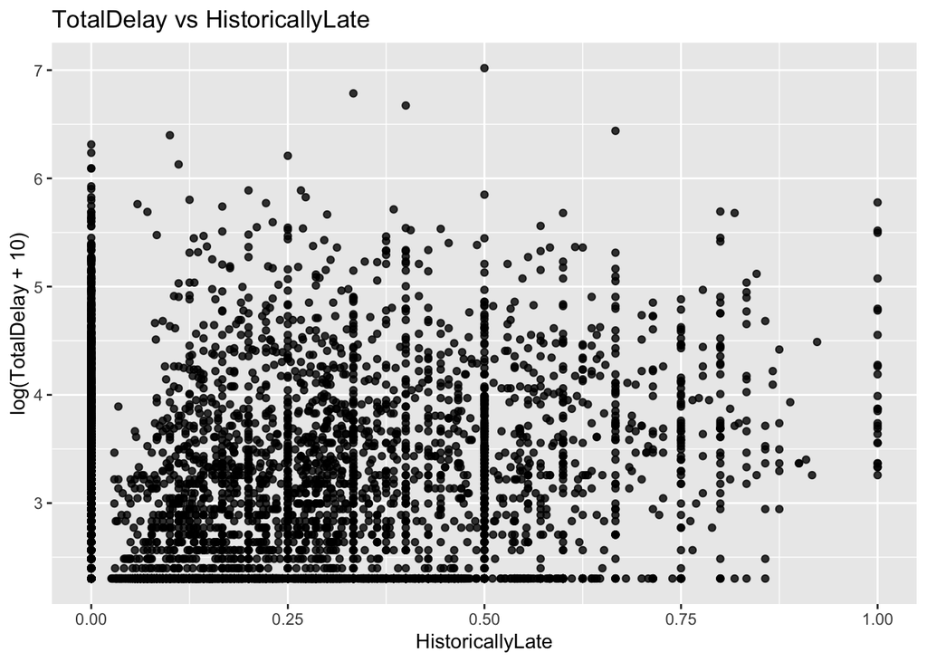

```r
# TotalDelay vs HistoricallyLate
ggplot(AirlinesTrain, aes(x=HistoricallyLate, y=log(TotalDelay+10))) +
  geom_point(alpha=0.8) + ggtitle("TotalDelay vs HistoricallyLate")
```

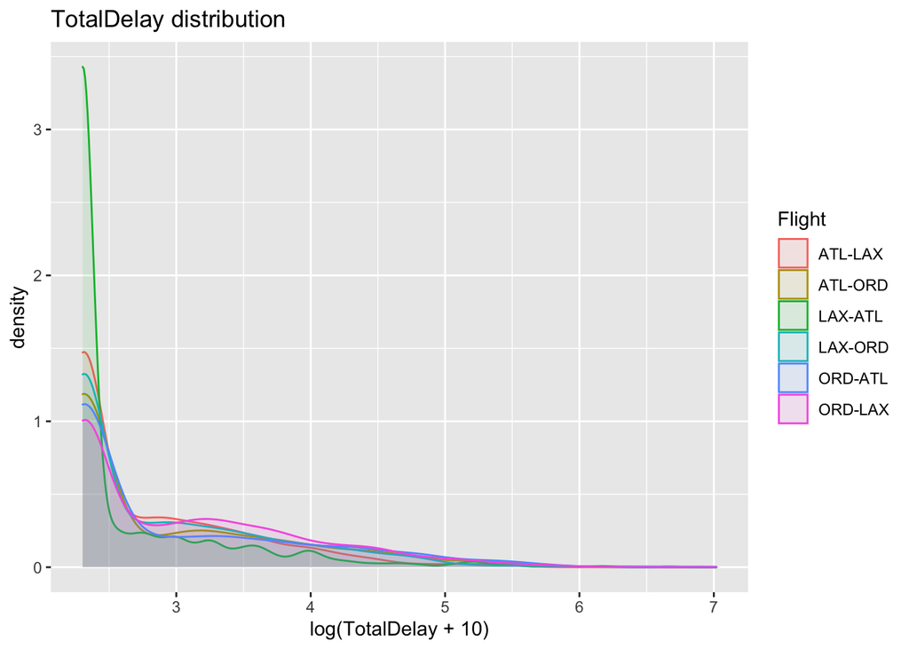

```r
# not a clear relation, maybe some non-linearities?

ggplot(AirlinesTrain, aes(log(TotalDelay+10))) + geom_density(aes(group=Flight, colour=Flight, fill=Flight), alpha=0.1) +
  ggtitle("TotalDelay distribution")
```

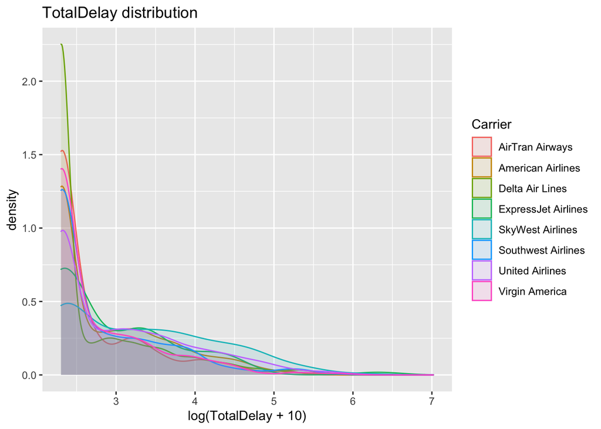

```r
# Not so many differences in the 6 flights, but LAX-ATL has less delays

ggplot(AirlinesTrain, aes(log(TotalDelay+10))) + geom_density(aes(group=Carrier, colour=Carrier, fill=Carrier), alpha=0.1) +
  ggtitle("TotalDelay distribution")
```

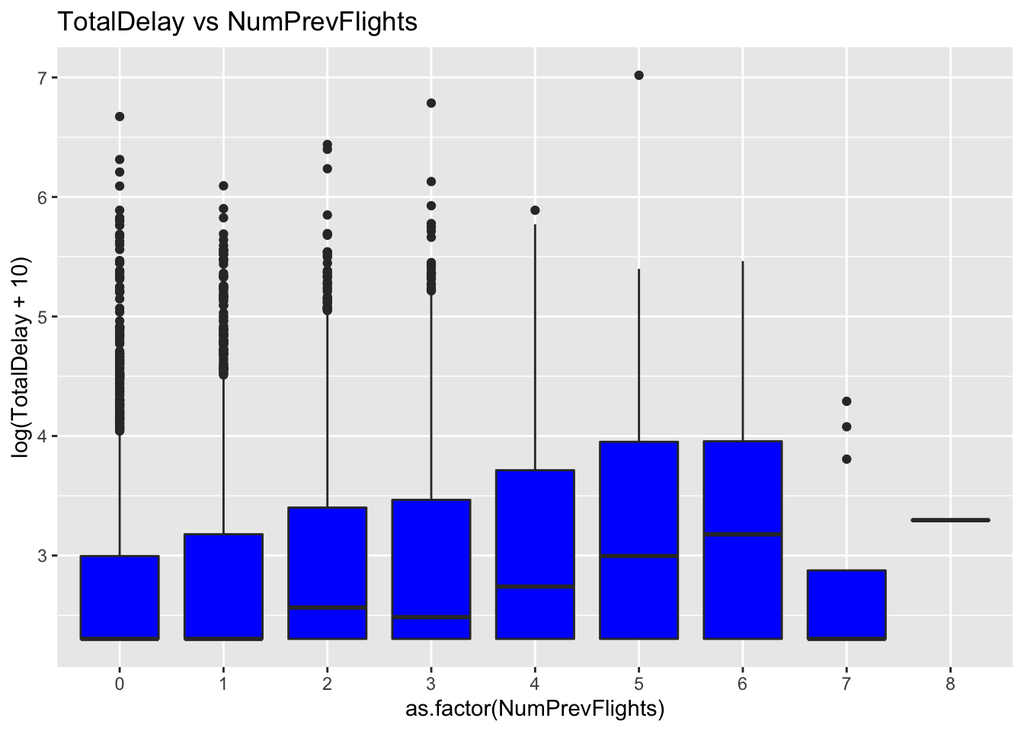

```r
# SkyWest Airlines seems to have more delays

ggplot(AirlinesTrain, aes(x=as.factor(NumPrevFlights), y=log(TotalDelay+10))) + geom_boxplot(fill="blue") +
  ggtitle("TotalDelay vs NumPrevFlights")
```

```r
# number of previous flights seems to increase delay, in a monotic but non-linear way
```

Note for categorical variables it is better to use boxplots

For numerical variables, better scatter plots

And even more plots:

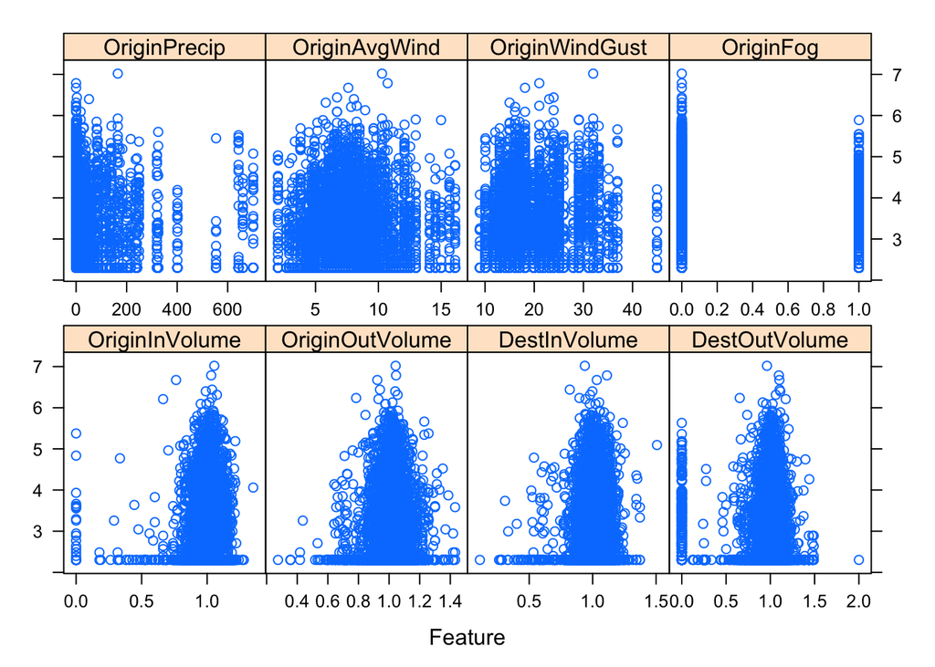

```r
featurePlot(x = AirlinesTrain[, c(9:16)],
            y = log(AirlinesTrain$TotalDelay+10),
            plot = "scatter",
            layout = c(4, 2))
```

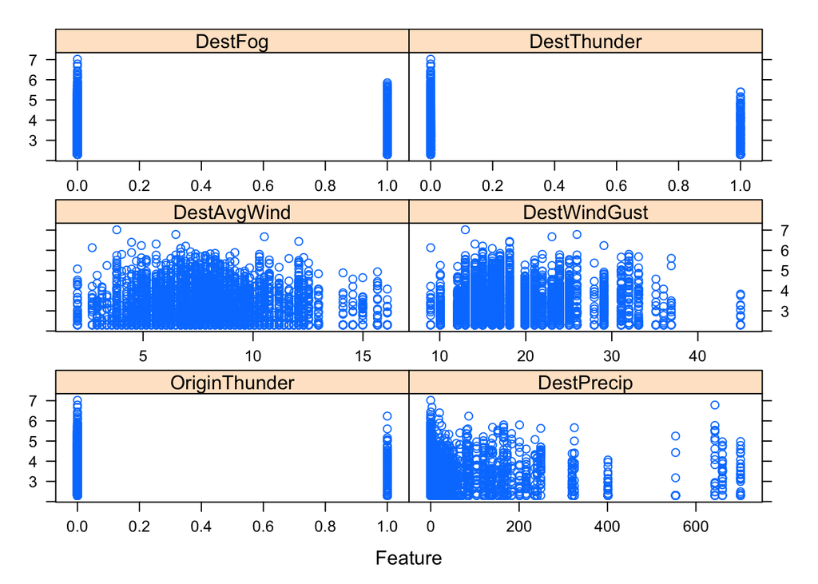

```r
# insights?

featurePlot(x = AirlinesTrain[, c(17:22)],
            y = log(AirlinesTrain$TotalDelay+10),
            plot = "scatter",
            layout = c(2, 3))
```

```r
# insights?
```

# A review of regression

Which are the most correlated variables with Delay?

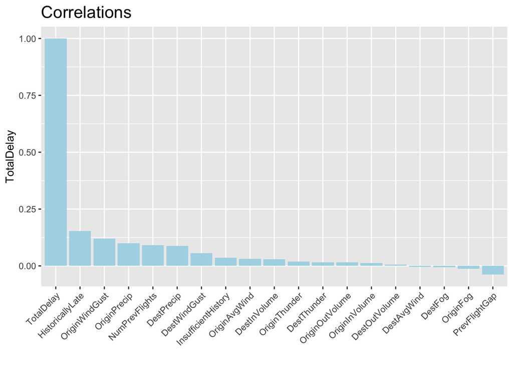

```r
corr_delay <- sort(cor(AirlinesTrain[,c(5:23)])["TotalDelay",], decreasing = T)
corr=data.frame(corr_delay)
ggplot(corr,aes(x = row.names(corr), y = corr_delay)) +
  geom_bar(stat = "identity", fill = "lightblue") +
  scale_x_discrete(limits= row.names(corr)) +
  labs(x = "", y = "TotalDelay", title = "Correlations") +
  theme(plot.title = element_text(hjust = 0, size = rel(1.5)),
        axis.text.x = element_text(angle = 45, hjust = 1))
```

Insights?

Simple regression: try first the most relevant predictor from previous analysis

```r
# Type here a simple regression model
```

Insights?

### Prediction

```r
# Type here the corresponding prediction in testing
```

Insights?

### Multiple regression

If we include more variables in the model, the prediction accuracy could be improved

Try some multiple regression models and compute performance measures in the testing set

```r
linFit <- lm(log(TotalDelay+10) ~ ., data=AirlinesTrain)
summary(linFit)
```

```
##
## Call:
## lm(formula = log(TotalDelay + 10) ~ ., data = AirlinesTrain)
##
## Residuals:
##     Min      1Q  Median      3Q     Max
## -1.8734 -0.4841 -0.1937  0.3661  3.8367
##
## Coefficients:
##                              Estimate Std. Error t value Pr(>|t|)
## (Intercept)                 1.295e+00  1.699e-01   7.622 2.80e-14 ***
## FlightATL-ORD              -1.869e-02  3.633e-02  -0.514 0.606933
## FlightLAX-ATL              -2.334e-02  3.286e-02  -0.710 0.477637
## FlightLAX-ORD              -7.454e-02  1.982e-01  -0.376 0.706821
## FlightORD-ATL               3.524e-02  3.766e-02   0.936 0.349404
## FlightORD-LAX               3.831e-02  1.982e-01   0.193 0.846739
## CarrierAmerican Airlines    6.056e-02  2.058e-01   0.294 0.768566
## CarrierDelta Air Lines     -5.094e-03  5.930e-02  -0.086 0.931545
## CarrierExpressJet Airlines  9.458e-02  1.071e-01   0.883 0.377312
## CarrierSkyWest Airlines     1.921e-01  8.099e-02   2.372 0.017724 *
## CarrierSouthwest Airlines  -1.119e-02  6.559e-02  -0.171 0.864519
## CarrierUnited Airlines      2.084e-01  2.044e-01   1.020 0.307926
## CarrierVirgin America       3.331e-02  2.092e-01   0.159 0.873516
## MonthJuly                  -1.121e-01  2.133e-02  -5.257 1.50e-07 ***
## MonthJune                  -5.190e-02  2.208e-02  -2.351 0.018769 *
## DayOfWeekMonday             3.476e-03  3.160e-02   0.110 0.912408
## DayOfWeekSaturday          -8.254e-02  3.407e-02  -2.423 0.015437 *
## DayOfWeekSunday            -8.481e-02  3.224e-02  -2.630 0.008547 **
## DayOfWeekThursday           5.858e-02  3.193e-02   1.835 0.066562 .
## DayOfWeekTuesday           -2.272e-02  3.281e-02  -0.692 0.488647
## DayOfWeekWednesday          7.540e-02  3.218e-02   2.343 0.019156 *
## NumPrevFlights              3.491e-02  8.244e-03   4.234 2.32e-05 ***
## PrevFlightGap               7.024e-05  1.334e-04   0.526 0.598625
## HistoricallyLate            1.337e+00  5.465e-02  24.466  < 2e-16 ***
## InsufficientHistory         4.036e-01  2.626e-02  15.370  < 2e-16 ***
## OriginInVolume              1.260e-01  8.308e-02   1.516 0.129457
## OriginOutVolume             3.494e-01  1.043e-01   3.351 0.000810 ***
## DestInVolume                2.518e-01  1.077e-01   2.338 0.019399 *
## DestOutVolume               3.847e-02  3.695e-02   1.041 0.297858
## OriginPrecip                5.923e-04  1.061e-04   5.581 2.48e-08 ***
## OriginAvgWind              -1.676e-02  4.846e-03  -3.459 0.000545 ***
## OriginWindGust              1.985e-02  2.129e-03   9.326  < 2e-16 ***
## OriginFog                   2.376e-02  2.723e-02   0.873 0.382961
## OriginThunder               4.127e-02  5.431e-02   0.760 0.447273
## DestPrecip                  7.182e-04  1.054e-04   6.814 1.02e-11 ***
## DestAvgWind                -1.631e-02  4.880e-03  -3.341 0.000839 ***
## DestWindGust                1.383e-02  2.170e-03   6.374 1.96e-10 ***
## DestFog                    -6.461e-02  2.741e-02  -2.357 0.018440 *
## DestThunder                 1.448e-01  5.187e-02   2.791 0.005266 **
## ---
## Signif. codes:  0 '***' 0.001 '**' 0.01 '*' 0.05 '.' 0.1 ' ' 1
##
## Residual standard error: 0.7211 on 7467 degrees of freedom
## Multiple R-squared:  0.1803, Adjusted R-squared:  0.1761
## F-statistic: 43.22 on 38 and 7467 DF,  p-value: < 2.2e-16
```

Prediction:

```r
pred.log <- predict(linFit, newdata=AirlinesTest)
cor(log(AirlinesTest$TotalDelay+10), pred.log)^2
```

```
## [1] 0.1985194
```

Many variables non-significant: high collinearity, not useful to explain (overfitting)

But useful to predict: R2 is roughly 20% in the testing

Other performance measures: MAPE and RMSE

```r
# Error in percentage (mape):
MAPE = mean(abs(log(AirlinesTest$TotalDelay+10)- pred.log)/log(AirlinesTest$TotalDelay+10))
MAPE
```

```
## [1] 0.1812201
```

```r
# Testing residual standard-error:
RMSE <- sqrt(mean((pred.log - log(AirlinesTest$TotalDelay+10))^2))
RMSE
```

```
## [1] 0.7049455
```

```r
# this is similar to the Residual standard error in summary(linFit) because units are in logs

# This is the RMSE in minutes:
sqrt(mean(((exp(pred.log)-10) - AirlinesTest$TotalDelay)^2))
```

```
## [1] 35.64488
```

# Advanced regression models

A basic multiple regression model with interactions:

```r
linFit <- lm(log(TotalDelay+10) ~ OriginAvgWind + OriginPrecip + DestAvgWind + DestPrecip + HistoricallyLate +
               OriginPrecip:DestPrecip, data=AirlinesTrain)

summary(linFit)
```

```
##
## Call:
## lm(formula = log(TotalDelay + 10) ~ OriginAvgWind + OriginPrecip +
##     DestAvgWind + DestPrecip + HistoricallyLate + OriginPrecip:DestPrecip,
##     data = AirlinesTrain)
##
## Residuals:
##     Min      1Q  Median      3Q     Max
## -1.9062 -0.4996 -0.3234  0.3877  3.7267
##
## Coefficients:
##                           Estimate Std. Error t value Pr(>|t|)
## (Intercept)              2.410e+00  4.666e-02  51.636  < 2e-16 ***
## OriginAvgWind            2.021e-02  3.831e-03   5.276 1.36e-07 ***
## OriginPrecip             1.150e-03  1.026e-04  11.210  < 2e-16 ***
## DestAvgWind              1.069e-02  3.830e-03   2.790  0.00528 **
## DestPrecip               9.849e-04  1.020e-04   9.656  < 2e-16 ***
## HistoricallyLate         9.411e-01  4.247e-02  22.161  < 2e-16 ***
## OriginPrecip:DestPrecip -1.931e-06  1.145e-06  -1.686  0.09177 .
## ---
## Signif. codes:  0 '***' 0.001 '**' 0.01 '*' 0.05 '.' 0.1 ' ' 1
##
## Residual standard error: 0.7588 on 7499 degrees of freedom
## Multiple R-squared:  0.08859,    Adjusted R-squared:  0.08786
## F-statistic: 121.5 on 6 and 7499 DF,  p-value: < 2.2e-16
```

```r
pred.log <- predict(linFit, newdata=AirlinesTest)
cor(log(AirlinesTest$TotalDelay+10), pred.log)^2
```

```
## [1] 0.1119203
```

R2 in the training is 10%

R2 in the testing is around 10%

An even more advanced model using categorical variables: for instance, Flight has 6 categories but R creates 5 dummies, why?

Useful to incorporate interactions between categorical variables and numeric ones

```r
linFit <- lm(log(TotalDelay+10) ~ Flight*(OriginAvgWind+OriginPrecip+DestAvgWind+DestPrecip+OriginWindGust+HistoricallyLate)+I(HistoricallyLate^2)+OriginPrecip:DestPrecip, data=AirlinesTrain)
summary(linFit)
```

```
##
## Call:
## lm(formula = log(TotalDelay + 10) ~ Flight * (OriginAvgWind +
##     OriginPrecip + DestAvgWind + DestPrecip + OriginWindGust +
##     HistoricallyLate) + I(HistoricallyLate^2) + OriginPrecip:DestPrecip,
##     data = AirlinesTrain)
##
## Residuals:
##     Min      1Q  Median      3Q     Max
## -1.9066 -0.4939 -0.2414  0.3655  3.8053
##
## Coefficients:
##                                  Estimate Std. Error t value Pr(>|t|)
## (Intercept)                     2.218e+00  1.807e-01  12.279  < 2e-16 ***
## FlightATL-ORD                  -2.071e-01  2.231e-01  -0.929 0.353148
## FlightLAX-ATL                   4.848e-01  2.751e-01   1.762 0.078042 .
## FlightLAX-ORD                   9.982e-01  2.453e-01   4.069 4.76e-05 ***
## FlightORD-ATL                  -5.211e-02  2.190e-01  -0.238 0.811948
## FlightORD-LAX                   4.752e-01  2.369e-01   2.006 0.044897 *
## OriginAvgWind                   4.433e-03  1.061e-02   0.418 0.676001
## OriginPrecip                    1.172e-03  2.538e-04   4.617 3.96e-06 ***
## DestAvgWind                     1.643e-02  1.901e-02   0.864 0.387516
## DestPrecip                     -5.788e-03  5.971e-03  -0.969 0.332413
## OriginWindGust                  1.481e-02  3.920e-03   3.777 0.000160 ***
## HistoricallyLate               -3.590e-01  1.473e-01  -2.437 0.014823 *
## I(HistoricallyLate^2)           1.934e+00  1.670e-01  11.582  < 2e-16 ***
## FlightATL-ORD:OriginAvgWind     6.776e-03  1.620e-02   0.418 0.675745
## FlightLAX-ATL:OriginAvgWind    -2.208e-02  2.697e-02  -0.819 0.413011
## FlightLAX-ORD:OriginAvgWind     1.043e-02  2.340e-02   0.445 0.655979
## FlightORD-ATL:OriginAvgWind    -4.786e-02  1.647e-02  -2.906 0.003670 **
## FlightORD-LAX:OriginAvgWind    -3.344e-02  1.394e-02  -2.398 0.016517 *
## FlightATL-ORD:OriginPrecip     -4.069e-04  3.711e-04  -1.096 0.272904
## FlightLAX-ATL:OriginPrecip     -1.594e-03  6.205e-03  -0.257 0.797232
## FlightLAX-ORD:OriginPrecip      2.230e-03  4.508e-03   0.495 0.620877
## FlightORD-ATL:OriginPrecip     -1.796e-04  3.486e-04  -0.515 0.606368
## FlightORD-LAX:OriginPrecip     -9.060e-04  3.023e-04  -2.997 0.002732 **
## FlightATL-ORD:DestAvgWind       2.283e-02  2.120e-02   1.077 0.281567
## FlightLAX-ATL:DestAvgWind      -3.648e-02  2.141e-02  -1.704 0.088488 .
## FlightLAX-ORD:DestAvgWind      -2.477e-02  2.019e-02  -1.227 0.219798
## FlightORD-ATL:DestAvgWind      -1.839e-02  2.224e-02  -0.827 0.408314
```

[output cut: 8 more lines]

```
## FlightLAX-ORD:OriginWindGust   -4.327e-02  1.216e-02  -3.557 0.000377 ***
## FlightORD-ATL:OriginWindGust    3.158e-02  7.088e-03   4.455 8.49e-06 ***
## FlightORD-LAX:OriginWindGust    1.028e-02  5.798e-03   1.774 0.076138 .
## FlightATL-ORD:HistoricallyLate  2.713e-01  1.486e-01   1.826 0.067954 .
## FlightLAX-ATL:HistoricallyLate  1.050e+00  2.001e-01   5.249 1.57e-07 ***
## FlightLAX-ORD:HistoricallyLate  7.129e-02  1.387e-01   0.514 0.607144
## FlightORD-ATL:HistoricallyLate  4.918e-01  1.503e-01   3.273 0.001071 **
## FlightORD-LAX:HistoricallyLate -4.449e-01  1.253e-01  -3.550 0.000388 ***
## OriginPrecip:DestPrecip        -5.400e-06  1.359e-06  -3.974 7.14e-05 ***
## ---
## Signif. codes:  0 '***' 0.001 '**' 0.01 '*' 0.05 '.' 0.1 ' ' 1
##
## Residual standard error: 0.7366 on 7462 degrees of freedom
## Multiple R-squared:  0.1454, Adjusted R-squared:  0.1405
## F-statistic: 29.53 on 43 and 7462 DF,  p-value: < 2.2e-16
```

```r
pred.log <- predict(linFit, newdata=AirlinesTest)
cor(log(AirlinesTest$TotalDelay+10), pred.log)^2
```

```
## [1] 0.1484079
```

R2 in the training is 14%

R2 in the testing is around 14%

Note the multiple regression model including all the variables is still the best

**Important question:** how do we know we are doing well?

Always consider a benchmark model (or a reference)

For instance, we can predict all the new delays as the average delay in the training set

```r
mean(log(AirlinesTrain$TotalDelay+10))
```

```
## [1] 2.881373
```

```r
# This is equivalent to
benchFit <- lm(log(TotalDelay+10) ~ 1, data=AirlinesTrain)
pred.bench <- predict(benchFit, newdata=AirlinesTest)
```

```r
cor(log(AirlinesTest$TotalDelay+10), pred.bench)^2
```

Why cannot we compute the R2?

```r
mean(abs(log(AirlinesTest$TotalDelay+10)- pred.bench)/log(AirlinesTest$TotalDelay+10))
```

```
## [1] 0.2162612
```

```r
sqrt(mean((pred.bench - log(AirlinesTest$TotalDelay+10))^2))
```

```
## [1] 0.7873729
```

The naive prediction is about 10% worse than our best model

# Robust Regression

Choose any of the next models (or any other):

```r
model = log(TotalDelay+10) ~ Flight*(OriginAvgWind+OriginPrecip+DestAvgWind+DestPrecip+OriginWindGust+HistoricallyLate)+I(HistoricallyLate^2)+OriginPrecip:DestPrecip

model = log(TotalDelay+10) ~ .

linFit <- lm(model, data=AirlinesTrain)
```

Residuals

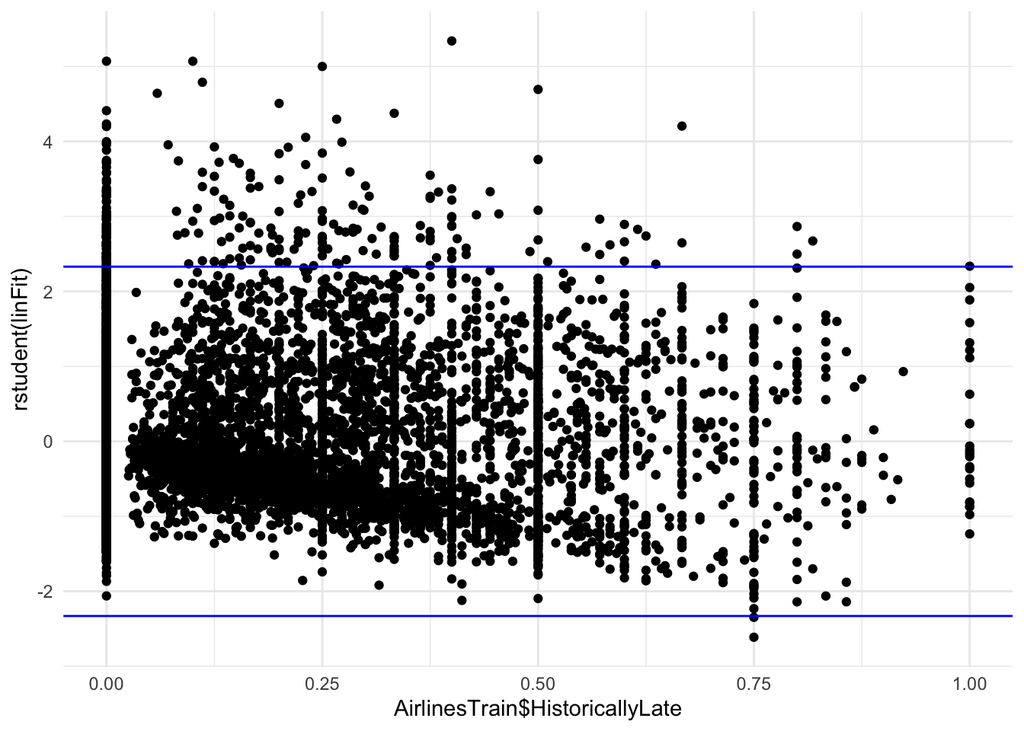

```r
ggplot() + aes(x=AirlinesTrain$HistoricallyLate, y=rstudent(linFit)) + geom_point() +
  geom_hline(yintercept=c(-2.33,2.33), color="blue") + theme_minimal()
```

Some outliers in the top (real delays bigger than expected)

Diagnostic plots: residuals, fitted values, Cook’s distance, and leverage

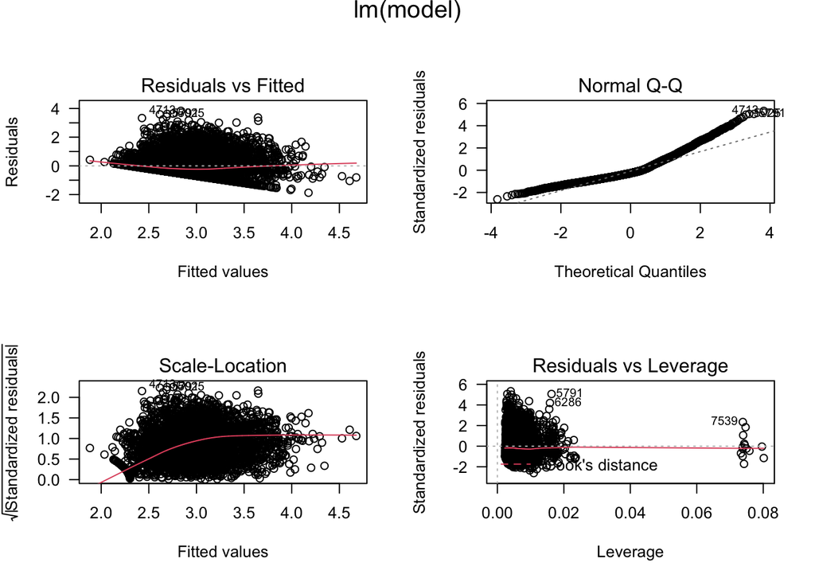

```r
opar <- par(mfrow = c(2,2), oma = c(0, 0, 1.1, 0))
plot(linFit, las = 1)
```

Some outliers

Prediction

```r
prLM <- predict(linFit, newdata=AirlinesTest)
cor(log(AirlinesTest$TotalDelay+10), prLM)^2
```

```
## [1] 0.1985194
```

```r
mean(abs(log(AirlinesTest$TotalDelay+10)- prLM)/log(AirlinesTest$TotalDelay+10))
```

```
## [1] 0.1812201
```

## Huber estimation

```r
linfit.huber <- rlm(model, data=AirlinesTrain)
summary(linfit.huber)
```

```
##
## Call: rlm(formula = model, data = AirlinesTrain)
## Residuals:
##     Min      1Q  Median      3Q     Max
## -1.7163 -0.3942 -0.1211  0.4573  3.9225
##
## Coefficients:
##                            Value   Std. Error t value
## (Intercept)                 1.3938  0.1482     9.4036
## FlightATL-ORD              -0.0627  0.0317    -1.9795
## FlightLAX-ATL              -0.0468  0.0287    -1.6344
## FlightLAX-ORD              -0.1384  0.1728    -0.8009
## FlightORD-ATL              -0.0352  0.0328    -1.0703
## FlightORD-LAX              -0.0364  0.1728    -0.2107
## CarrierAmerican Airlines    0.1032  0.1795     0.5748
## CarrierDelta Air Lines      0.0025  0.0517     0.0491
## CarrierExpressJet Airlines  0.0957  0.0934     1.0244
## CarrierSkyWest Airlines     0.2042  0.0706     2.8902
## CarrierSouthwest Airlines  -0.0276  0.0572    -0.4826
## CarrierUnited Airlines      0.2296  0.1782     1.2881
## CarrierVirgin America       0.0732  0.1825     0.4014
## MonthJuly                  -0.0830  0.0186    -4.4635
## MonthJune                  -0.0187  0.0193    -0.9728
## DayOfWeekMonday             0.0118  0.0276     0.4280
## DayOfWeekSaturday          -0.0758  0.0297    -2.5492
## DayOfWeekSunday            -0.0616  0.0281    -2.1913
## DayOfWeekThursday           0.0321  0.0278     1.1512
## DayOfWeekTuesday           -0.0098  0.0286    -0.3432
## DayOfWeekWednesday          0.0492  0.0281     1.7529
## NumPrevFlights              0.0267  0.0072     3.7149
## PrevFlightGap              -0.0001  0.0001    -0.7876
## HistoricallyLate            1.2943  0.0477    27.1555
## InsufficientHistory         0.3599  0.0229    15.7160
## OriginInVolume              0.1531  0.0725     2.1126
## OriginOutVolume             0.3512  0.0909     3.8616
## DestInVolume                0.1734  0.0939     1.8466
## DestOutVolume               0.0403  0.0322     1.2520
## OriginPrecip                0.0005  0.0001     5.7847
## OriginAvgWind              -0.0135  0.0042    -3.1839
## OriginWindGust              0.0163  0.0019     8.7902
## OriginFog                   0.0164  0.0237     0.6886
## OriginThunder               0.0433  0.0474     0.9134
## DestPrecip                  0.0006  0.0001     6.8441
## DestAvgWind                -0.0140  0.0043    -3.2866
## DestWindGust                0.0110  0.0019     5.8336
## DestFog                    -0.0622  0.0239    -2.6037
## DestThunder                 0.1258  0.0452     2.7805
##
## Residual standard error: 0.6054 on 7467 degrees of freedom
```

Prediction

```r
prHuber <- predict(linfit.huber, newdata=AirlinesTest)

cor(log(AirlinesTest$TotalDelay+10), prHuber)^2
```

```
## [1] 0.1990717
```

```r
mean(abs(log(AirlinesTest$TotalDelay+10)- prHuber)/log(AirlinesTest$TotalDelay+10))
```

```
## [1] 0.1693661
```

## Bi-square estimation

```r
linfit.bisquare <- rlm(model, data=AirlinesTrain, psi = psi.bisquare)
summary(linfit.bisquare)
```

```
##
## Call: rlm(formula = model, data = AirlinesTrain, psi = psi.bisquare)
## Residuals:
##      Min       1Q   Median       3Q      Max
## -1.66063 -0.36512 -0.09492  0.48211  3.95853
##
## Coefficients:
##                            Value   Std. Error t value
## (Intercept)                 1.4300  0.1482     9.6490
## FlightATL-ORD              -0.0788  0.0317    -2.4872
## FlightLAX-ATL              -0.0564  0.0287    -1.9686
## FlightLAX-ORD              -0.1674  0.1728    -0.9688
## FlightORD-ATL              -0.0611  0.0328    -1.8619
## FlightORD-LAX              -0.0744  0.1728    -0.4307
## CarrierAmerican Airlines    0.1351  0.1795     0.7526
## CarrierDelta Air Lines      0.0061  0.0517     0.1177
## CarrierExpressJet Airlines  0.0975  0.0934     1.0434
## CarrierSkyWest Airlines     0.2208  0.0706     3.1255
## CarrierSouthwest Airlines  -0.0375  0.0572    -0.6559
## CarrierUnited Airlines      0.2500  0.1782     1.4031
## CarrierVirgin America       0.1030  0.1825     0.5645
## MonthJuly                  -0.0735  0.0186    -3.9516
## MonthJune                  -0.0086  0.0193    -0.4489
## DayOfWeekMonday             0.0261  0.0276     0.9466
## DayOfWeekSaturday          -0.0677  0.0297    -2.2772
## DayOfWeekSunday            -0.0502  0.0281    -1.7845
## DayOfWeekThursday           0.0294  0.0278     1.0571
## DayOfWeekTuesday            0.0049  0.0286     0.1702
## DayOfWeekWednesday          0.0433  0.0281     1.5417
## NumPrevFlights              0.0253  0.0072     3.5144
## PrevFlightGap              -0.0002  0.0001    -1.4021
## HistoricallyLate            1.2809  0.0477    26.8801
## InsufficientHistory         0.3476  0.0229    15.1801
## OriginInVolume              0.1616  0.0724     2.2309
## OriginOutVolume             0.3522  0.0909     3.8727
## DestInVolume                0.1344  0.0939     1.4312
## DestOutVolume               0.0450  0.0322     1.3954
## OriginPrecip                0.0005  0.0001     5.5356
## OriginAvgWind              -0.0124  0.0042    -2.9289
## OriginWindGust              0.0149  0.0019     8.0036
## OriginFog                   0.0173  0.0237     0.7283
## OriginThunder               0.0585  0.0474     1.2349
## DestPrecip                  0.0006  0.0001     6.0324
## DestAvgWind                -0.0132  0.0043    -3.0943
## DestWindGust                0.0103  0.0019     5.4360
## DestFog                    -0.0621  0.0239    -2.5977
## DestThunder                 0.1360  0.0452     3.0075
##
## Residual standard error: 0.5845 on 7467 degrees of freedom
```

Prediction

```r
prBi <- predict(linfit.bisquare, newdata=AirlinesTest)

cor(log(AirlinesTest$TotalDelay+10), prBi)^2
```

```
## [1] 0.1978667
```

```r
mean(abs(log(AirlinesTest$TotalDelay+10)- prBi)/log(AirlinesTest$TotalDelay+10))
```

```
## [1] 0.1659985
```

Some improvement

When comparing the results of OLS regression with robust regression, if the results are very different, better to use the results from the robust regression: more reliable

Large differences suggest that the model parameters are being highly influenced by outliers

Different loss functions have advantages and drawbacks. Huber weights can have difficulties with severe outliers, and bisquare weights can have difficulties converging or may yield multiple solutions

# An introduction to Caret

Highly recommended package

- to evaluate performance and calibrate sensitive parameters
- to choose the best model across these parameters
- to estimate model performance from a training set
- Main function: train()

tidymodels is the tidy version of caret (collection of packages for modelling)

These are the models for regression and classification:

```r
names(getModelInfo())
```

```
##   [1] "ada"                 "AdaBag"              "AdaBoost.M1"
##   [4] "adaboost"            "amdai"               "ANFIS"
##   [7] "avNNet"              "awnb"                "awtan"
##  [10] "bag"                 "bagEarth"            "bagEarthGCV"
##  [13] "bagFDA"              "bagFDAGCV"           "bam"
##  [16] "bartMachine"         "bayesglm"            "binda"
##  [19] "blackboost"          "blasso"              "blassoAveraged"
##  [22] "bridge"              "brnn"                "BstLm"
##  [25] "bstSm"               "bstTree"             "C5.0"
##  [28] "C5.0Cost"            "C5.0Rules"           "C5.0Tree"
##  [31] "cforest"             "chaid"               "CSimca"
##  [34] "ctree"               "ctree2"              "cubist"
##  [37] "dda"                 "deepboost"           "DENFIS"
##  [40] "dnn"                 "dwdLinear"           "dwdPoly"
##  [43] "dwdRadial"           "earth"               "elm"
```

[output cut: 65 more lines]

## Tuning

Each model can be automatically tuned and evaluated

Example: use 5 repeats of 10-fold cross validation

```r
ctrl <- trainControl(method = "repeatedcv",
                     repeats = 5,
                     number = 10)
```

We can also choose bootstrap, LOOCV, etc.

If we want to fix the hyper-parameters (no tuning), then no trainControl is needed

```r
ctrl <- trainControl(method = "none")
```

## The train function

This function sets up a grid of tuning parameters for a number of classification and regression routines, fits each model and calculates a resampling based performance measure

Let’s first save our predictions and real observations in a data frame

```r
test_results <- data.frame(TotalDelay = log(AirlinesTest$TotalDelay+10))

observed = log(AirlinesTest$TotalDelay+10)
```

Linear regression with Caret:

```r
lm_tune <- train(log(TotalDelay+10) ~ .,
                 data = AirlinesTrain,
                 method = "lm",
                 preProc=c('scale', 'center'),
                 trControl = ctrl)
```

Prediction

```r
test_results$lm <- predict(lm_tune, AirlinesTest)

postResample(pred = test_results$lm,  obs = observed)
```

```
##      RMSE  Rsquared       MAE
## 0.7049455 0.1985194 0.5425952
```

Plot

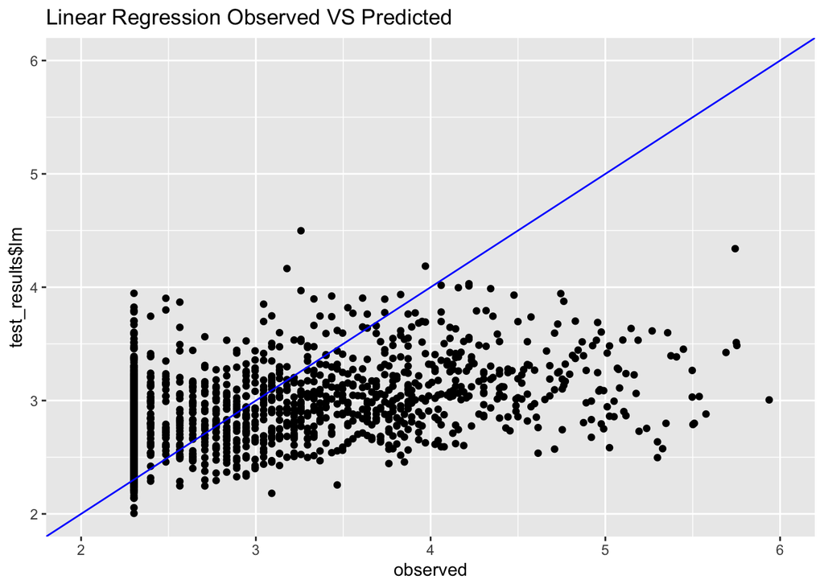

```r
qplot(observed, test_results$lm) +
  lims(x = c(2, 6), y = c(2, 6)) +
  geom_abline(intercept = 0, slope = 1, colour = "blue") +
  ggtitle("Linear Regression Observed VS Predicted")
```

Robust regression with Caret

Because here we have, we are going to use 5-fold cross validation for tuning

```r
ctrl <- trainControl(method = "repeatedcv",
                     number = 5)

# take care: rlm does not work very well with categorical variables
rlm_tune <- train(log(TotalDelay+10) ~ .,
                  data = AirlinesTrain[,c(-1,-2,-3,-4)],
                  method = "rlm",
                  preProc=c('scale', 'center'),
                  trControl = ctrl)

rlm_tune
```

```
## Robust Linear Model
##
## 7506 samples
##   18 predictor
##
## Pre-processing: scaled (18), centered (18)
## Resampling: Cross-Validated (5 fold, repeated 1 times)
## Summary of sample sizes: 6004, 6005, 6005, 6005, 6005
## Resampling results across tuning parameters:
##
##   intercept  psi           RMSE       Rsquared   MAE
##   FALSE      psi.huber     2.9722199  0.1579001  2.8813038
##   FALSE      psi.hampel    2.9722060  0.1578868  2.8812877
##   FALSE      psi.bisquare  2.9722269  0.1579036  2.8813053
##    TRUE      psi.huber     0.7355760  0.1571830  0.5441759
##    TRUE      psi.hampel    0.7305244  0.1576251  0.5538328
##    TRUE      psi.bisquare  0.7405167  0.1560878  0.5394595
##
## RMSE was used to select the optimal model using the smallest value.
## The final values used for the model were intercept = TRUE and psi = psi.hampel.
```

Numerically unstable…

Predict and plot

```r
test_results$rlm <- predict(rlm_tune, AirlinesTest[,c(-1,-2,-3,-4)])
postResample(pred = test_results$rlm,  obs = observed)
```

```
##      RMSE  Rsquared       MAE
## 0.7173460 0.1728044 0.5474362
```

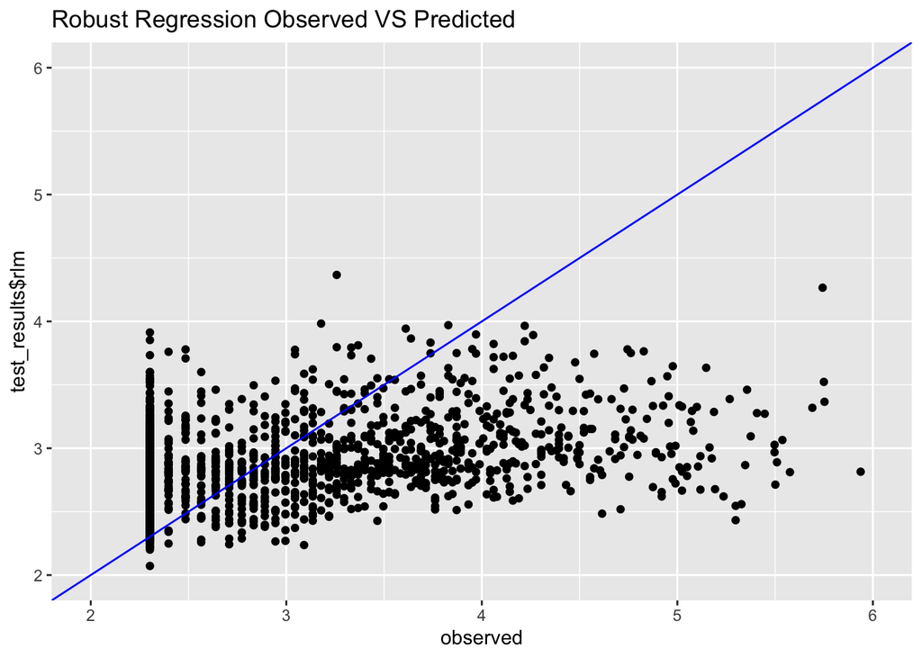

```r
qplot(observed, test_results$rlm) +
  lims(x = c(2, 6), y = c(2, 6)) +
  geom_abline(intercept = 0, slope = 1, colour = "blue") +
  ggtitle("Robust Regression Observed VS Predicted")
```